# Population structure: practical

Lewis Spurgin

## Introduction

In this practical we will be analysing population structure in a genomic dataset. By the end of the practical you should be able to employ some commonly used methods (FST, admixture, PCA) to detect and quantify population structure. We will also continue to develop our plotting skills in R.

## The data

We will be using a large SNP dataset from European great tit populations to explore continental-scale genomic structure. The data are stored as binary plink files in the ubuntu “population_structure” folder. **Make sure you have copied the population_structure folder to your home directory using the following command.**

```r
cd
cp -r Dati/population_structure .
```

## Instructions

### Data exploration and cleaning in plink

Before we clean our data, use the command line to explore .bed, .bim and .fam files to try to figure out how many individuals and SNP markers have been typed.

Now use what you have learned about plink and VCFtools, along with the plink website, to filter the dataset (HINT: filtering in plink and VCFtools is a very similar process!). You should filter based on Hardy-Weinberg and minor allele frequencies, selecting an appropriate threshold for each. Give your output the name “GreatTitsFiltered”.

```r
plink --bfile GreatTits --hwe 0.01 --maf 0.05 --make-bed --out GreatTitsFiltered
```

Note how we can add both `--hwe` and `--maf` options to a single command and used the same output name. This is more efficient and saves us space.

We will now “prune” our markers based on LD. Check out the options that plink has for this. See if you can figure out how to prune markers, using appropriate thresholds. You should perform this on the “GreatTitsFiltered” binary plink files you have just created. Then take a look what I have chosen below:

```r
plink --bfile GreatTitsFiltered --indep-pairwise 50 10 0.05 --make-bed --out GreatTitsFiltered
```

I have chosen to prune in windows of 50 markers, shifting this window along 10 markers at a time. This is called a *sliding window*, and is something we will cover in more detail later in the course. The final argument (0.05) is the R^2 threshold of I chosen to prune with. Note that you can also use the Variance Inflation Factor (VIF), using the argument `--indep`. If you have chosen different thresholds that’s fine. This argument has written two lists of SNPs as output files - one list of SNPs in linkage equilibrium with one another, and one list of SNPs to be excluded. We can use either of these to filter our binary plink file to create a new dataset only containing markers in linkage equilibrium.

```r
plink --bfile GreatTitsFiltered --extract GreatTitsFiltered.prune.in --make-bed --out GreatTitsFilteredPruned
```

x Finally, we can filter based on individual relatedness. This is best done by inspecting patterns of pairwise relatedness in your dataset, but for the sake of time we will pick a cut-off of 0.4, in order to remove full sibs (why not 0.5?).

```r
plink --bfile GreatTitsFilteredPruned --rel-cutoff 0.4 --out GreatTitsFilteredPruned
plink --bfile GreatTitsFilteredPruned --keep GreatTitsFilteredPruned.rel.id --make-bed --out GreatTitsFilteredPrunedUnrel
```

We have rushed through this a little, but you should now have an idea about some of the processes that you can use to tidy your SNP data.

### Pairwise FST

Let’s now focus on looking at population structure. In the “population_structure” folder, you should be able to find a file called “pairwise_fst_plink.py” Take a look at this file using `nano`.

```r
nano pairwise_fst_plink.py
```

Can you work out what this python script is doing? Take a few minutes to go through each line and try to understand what it is achieving. Discuss with a colleague.

```r
python pairwise_fst_plink.py
```

Take a look at the output from the python script(either using `cat` or `nano`), and make sure you understand the format of the output (hint - explore the python script and discuss with your colleagues). We will later use this output to create an isolation by distance plot, but for now we will run some extra population structure analyses on the server.

### PCA

We can also use plink to generate a PCA of our genetic data. Again, we will use the pruned and cleaned dataset we generated earlier. Can you figure out how to run a PCA on this data, in which you keep the first four principal components?

```r
plink --bfile GreatTitsFilteredPrunedUnrel --pca 4 --out GreatTitsFilteredPrunedUnrel
```

Have a look at the output files and check you are happy with what you have got (hint - use the plink manual). Again, we will download our file for plotting soon.

### Admixture

Finally, we are going to run Admixture on our dataset. But first we need to do one more piece of cleaning. We still have a very large number of SNPs in our great tit dataset, and with this many individuals and SNPs it would take Admixture several hours to run. So we are going to thin our markers substantially for the purpose of this practical. Can you figure out, using plink, how to randomly select 1% of your markers and write them to a new file?

```r
plink --bfile GreatTitsFilteredPrunedUnrel --thin 0.01 --make-bed --out GreatTitsThinned
```

Now look up the admixture manual online. The software has been installed on the server, and can be called up by typing `admixture`. If you do this, you will see that at its most basic level you just need an input file and a value of K. We will stick with the program defaults for now. Try running admixture at k = 2 for your cleaned great tit dataset, using the following code.

```r
mkdir admixture #So current directory doesn't get too messy
cd admixture
admixture ../GreatTitsThinned.bed 2
```

Have a look at your outputs - you should see a file ending in “.P”, and one ending in “.Q”. Explore these files and see if you can figure out what each one is.

Typically with software like STRUCTURE or admixture, we wish to compare how genetic variation is structured across multiple values of *k* - usually from *k* = 2 to *k* = $N_{populations}$. We could do this by repeating the above command 8 times, with *k* ranging from 2 to 9. But a more efficient way would be to create a for loop in bash. Can you figure out how to do this?

```r
for K in `seq 2 9`;
do
  admixture ../GreatTitsThinned.bed $K;
done
```

Done! Now we can download all of our results and do some plots. Create a new folder called session4_output and copy the following files to that folder:

- The pairwise FST output from the python script
- The file LatLong.txt
- The output from your plink PCA (the “.eigenvec” file)
- All of your admixture “.Q” files
- The file “GreatTitsThinned.fam”
- The R script “Admixture_plot.R”

Now download the session4_output folder using scp or pscp.

### Putting it all together

Once again, we will start be giving you the end product of this practical. The plot below is what you should be aiming for. Hopefully you can see that we have an IBD plot on the top left, a PCA on the bottom-left, then on the right we have three structure-type bar plots with K ranging from 2-4. If you feel as though you can have a go at this without step-by-step instruction, please go ahead now. Otherwise, full instructions are given below.

[figure not shown]

We will begin with the IBD plot. Hopefully it is clear that to reproduce this we need pairwise FST values, and corresponding geographic distances between populations. We calculated pairwise FST values using our python scripts. Let’s read that output in.

```r
pd <- read_delim("pairwise_fst.txt", delim = "\t",col_names = F)
pd
```

```
## # A tibble: 36 x 3
##    X1                 X2                       X3
##    <chr>              <chr>                 <dbl>
##  1 Mariola_Spain      Pirio_Muro_Corsica   0.0361
##  2 Mariola_Spain      Vienna_Austria       0.0122
##  3 Mariola_Spain      Loch_Lomond_Scotland 0.0233
##  4 Mariola_Spain      Oulu_Finland         0.0163
##  5 Mariola_Spain      Vlieland_NL          0.0204
##  6 Mariola_Spain      Montpellier_France   0.0172
##  7 Mariola_Spain      Zurich_Switzerland   0.0164
##  8 Mariola_Spain      Zvenigorod_Russia    0.0126
##  9 Pirio_Muro_Corsica Vienna_Austria       0.0261
## 10 Pirio_Muro_Corsica Loch_Lomond_Scotland 0.0372
## # … with 26 more rows
```

As we did not give this table column names in our python script, R has generated some automatically. Let’s give our data frame some names that make more sense.

```r
colnames(pd) <- c("p1","p2","FST")
```

Our next task is to calculate pairwise distance between each of our populations. We could go to Google maps and do this manually, but thankfully we can do it in R! Have a look at the `distGeo()` function in the `geosphere` library:

```r
library(geosphere)
?distGeo
```

`distGeo()` calculates the pairwise distance between two points - all you need to do is give it the longitude and latitude of the two points. We have longitude and latitude information in the file “LatLong.txt”. Read this file into R and take a look at it.

```r
ll <- read_delim("LatLong.txt", delim = "\t")
ll
```

```
## # A tibble: 27 x 3
##    Pop                    Lat   Long
##    <chr>                <dbl>  <dbl>
##  1 Antwerp_Belgium       51.2  4.39
##  2 Bulgaria              42.9 25.0
##  3 Cambridge_UK          52.2  0.152
##  4 Crete                 35.2 25.0
##  5 Font_Roja_Spain       38.7 -0.544
##  6 Gotland_Sweden        57.5 18.5
##  7 Harjavalta_Finland    61.3 22.1
##  8 Italy                 42.4 13.4
##  9 La_Rouviere_France    43.9  4.24
## 10 Loch_Lomond_Scotland  56.1 -4.56
## # … with 17 more rows
```

Let’s try calculating the distance in metres between the first pair of populations in our `pd` data frame, Mariola_Spain and Pirio_Muro_Corsica. We will first extract the latitude and longitude information for each of these populations, then use the `distGeo()` function to calculate the distance between them.

```r
#Extract population names from pd data frame
pop1 <- pd$p1[1] #First element of p1 column
pop2 <- pd$p2[1] #First element of p2 column

#Get lat and log information
l1 <- subset(ll,Pop == pop1)
l2 <- subset(ll,Pop == pop2)

#Now calculate distance
distGeo(p1 = c(l1$Long,l1$Lat),p2 = c(l2$Long,l2$Lat))
```

```
## [1] 965860.9
```

That looks about right! Now we need to calculate the distance between all of the population pairs in our data frame. Below I provide one ways that you can do this - using a `for` loop (DISCLAIMER - this is not the most efficient way of doing this, but it works). Discuss with your colleagues how you think the code is working.

```r
#Create an empty distance column
pd$dist <- NA

#Loop over the pd data frame
for(i in 1:nrow(pd))
{

#Extract population names from pd data frame
pop1 <- pd$p1[i] #First element of p1 column
pop2 <- pd$p2[i] #First element of p2 column

#Get lat and log information
l1 <- subset(ll,Pop == pop1)
l2 <- subset(ll,Pop == pop2)

#Now calculate distance
pd$dist[i] <- distGeo(p1 = c(l1$Long,l1$Lat),p2 = c(l2$Long,l2$Lat))

}

#Check that it's worked
head(pd)
```

```
## # A tibble: 6 x 4
##   p1            p2                      FST     dist
##   <chr>         <chr>                 <dbl>    <dbl>
## 1 Mariola_Spain Pirio_Muro_Corsica   0.0361  965861.
## 2 Mariola_Spain Vienna_Austria       0.0122 1806751.
## 3 Mariola_Spain Loch_Lomond_Scotland 0.0233 2065095.
## 4 Mariola_Spain Oulu_Finland         0.0163 3483616.
## 5 Mariola_Spain Vlieland_NL          0.0204 1778088.
## 6 Mariola_Spain Montpellier_France   0.0172  696738.
```

Now we have a distance column we can plot FST against distance, using your `ggplot2` skills from the last practical.

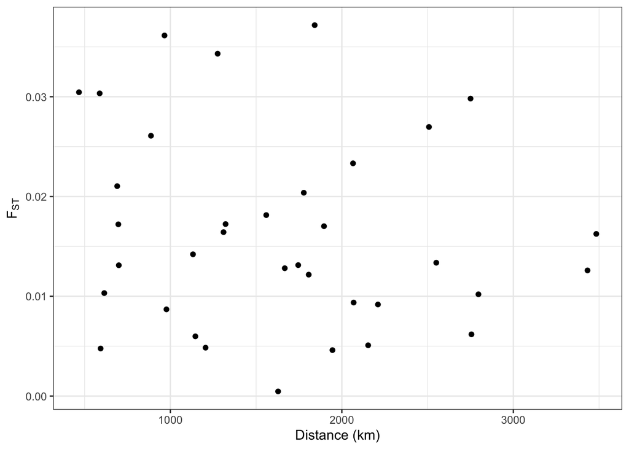

```r
A <- ggplot(pd,aes(x = dist/1000,y = FST))+ #divide by 1000 to get distance in km
  geom_point()+
  theme_bw()+
  xlab("Distance (km)")+
  ylab(expression("F"[ST]))

A
```

```r
pd[order(pd$FST,decreasing = T),]
```

```
## # A tibble: 36 x 4
##    p1                   p2                      FST     dist
##    <chr>                <chr>                 <dbl>    <dbl>
##  1 Pirio_Muro_Corsica   Loch_Lomond_Scotland 0.0372 1841551.
##  2 Mariola_Spain        Pirio_Muro_Corsica   0.0361  965861.
##  3 Pirio_Muro_Corsica   Vlieland_NL          0.0343 1275703.
##  4 Pirio_Muro_Corsica   Montpellier_France   0.0304  467186.
##  5 Pirio_Muro_Corsica   Zurich_Switzerland   0.0303  587823.
##  6 Pirio_Muro_Corsica   Oulu_Finland         0.0298 2750359.
##  7 Pirio_Muro_Corsica   Zvenigorod_Russia    0.0270 2508037.
##  8 Pirio_Muro_Corsica   Vienna_Austria       0.0261  886960.
##  9 Mariola_Spain        Loch_Lomond_Scotland 0.0233 2065095.
## 10 Loch_Lomond_Scotland Vlieland_NL          0.0210  690005.
## # … with 26 more rows
```

So bearing this in mind I though it would be good to show this group effect in my plot. Can you make a column in pd that tells us whether *either* of your populations is “Pirio_Muro_Corsica”?

```r
pd$Comparison <- ifelse(pd$p1 == "Pirio_Muro_Corsica" | pd$p2 == "Pirio_Muro_Corsica", "Mainland-Island","Mainland-Mainland")
```

Now we can make the full plot. Note the use of `scale_colour_manual()` to change the colours we use in ggplot.

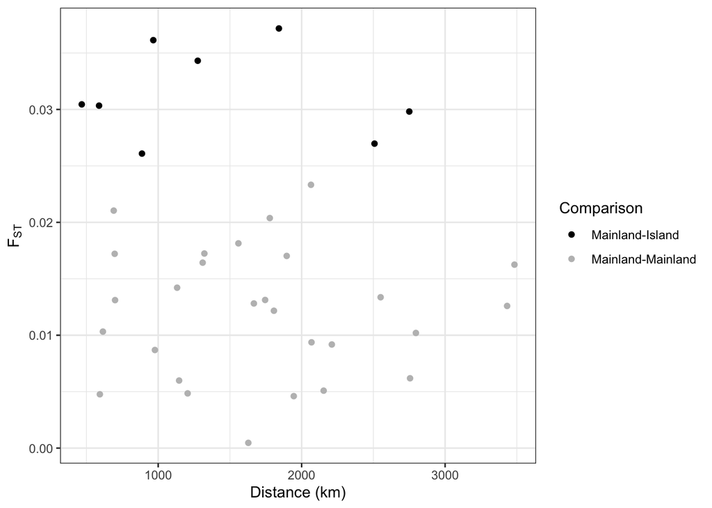

```r
A <- ggplot(pd,aes(x = dist/1000,y = FST,col = Comparison))+ #divide by 1000 to get distance in km
      geom_point()+
      theme_bw()+
      xlab("Distance (km)")+
      ylab(expression("F"[ST]))+
      scale_colour_manual(values = c("black","grey"))

A
```

Now we can move onto our PCA plot. Load the PCA output into R.

```r
pca1 <- read_delim("GreatTitsFilteredPrunedUnrel.eigenvec", delim = " ",col_names = F)
head(pca1)
```

```
## # A tibble: 6 x 6
##   X1                      X2      X3     X4        X5     X6
##   <chr>                <dbl>   <dbl>  <dbl>     <dbl>  <dbl>
## 1 Loch_Lomond_Scotland   238 -0.0291 0.0868 -0.000190 0.0178
## 2 Loch_Lomond_Scotland   240 -0.0387 0.259  -0.0123   0.0674
## 3 Loch_Lomond_Scotland   241 -0.0397 0.248  -0.00714  0.0605
## 4 Loch_Lomond_Scotland   244 -0.0372 0.226  -0.00928  0.0542
## 5 Loch_Lomond_Scotland   246 -0.0343 0.212  -0.0145   0.0469
## 6 Loch_Lomond_Scotland   248 -0.0279 0.136  -0.00304  0.0177
```

Once again we do not have sensible column names, so let’s create these ourselves.

```r
colnames(pca1) <- c("Population","Individual",paste0("PC",c(1:4)))
head(pca1)
```

```
## # A tibble: 6 x 6
##   Population           Individual     PC1    PC2       PC3    PC4
##   <chr>                     <dbl>   <dbl>  <dbl>     <dbl>  <dbl>
## 1 Loch_Lomond_Scotland        238 -0.0291 0.0868 -0.000190 0.0178
## 2 Loch_Lomond_Scotland        240 -0.0387 0.259  -0.0123   0.0674
## 3 Loch_Lomond_Scotland        241 -0.0397 0.248  -0.00714  0.0605
## 4 Loch_Lomond_Scotland        244 -0.0372 0.226  -0.00928  0.0542
## 5 Loch_Lomond_Scotland        246 -0.0343 0.212  -0.0145   0.0469
## 6 Loch_Lomond_Scotland        248 -0.0279 0.136  -0.00304  0.0177
```

What is the function `paste0()` doing there? (hint: try running the function on its own).

Now we are ready to make the plot. By now, you should be able to do this yourselves.

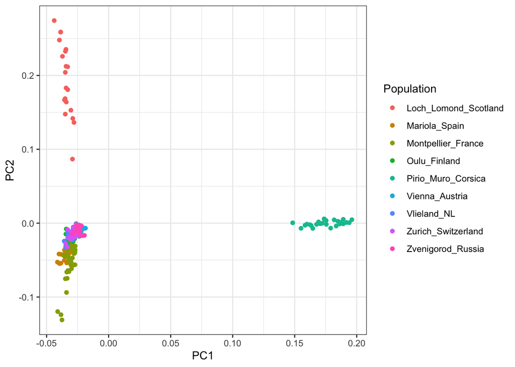

```r
B <- ggplot(pca1,aes(x = PC1,y = PC2,col = Population))+
      geom_point()+
      theme_bw()
B
```

Perfect - all we need to do now is cosmetics. To change the colours you need to specify nine different colours. Have a play about with this, or use mine:

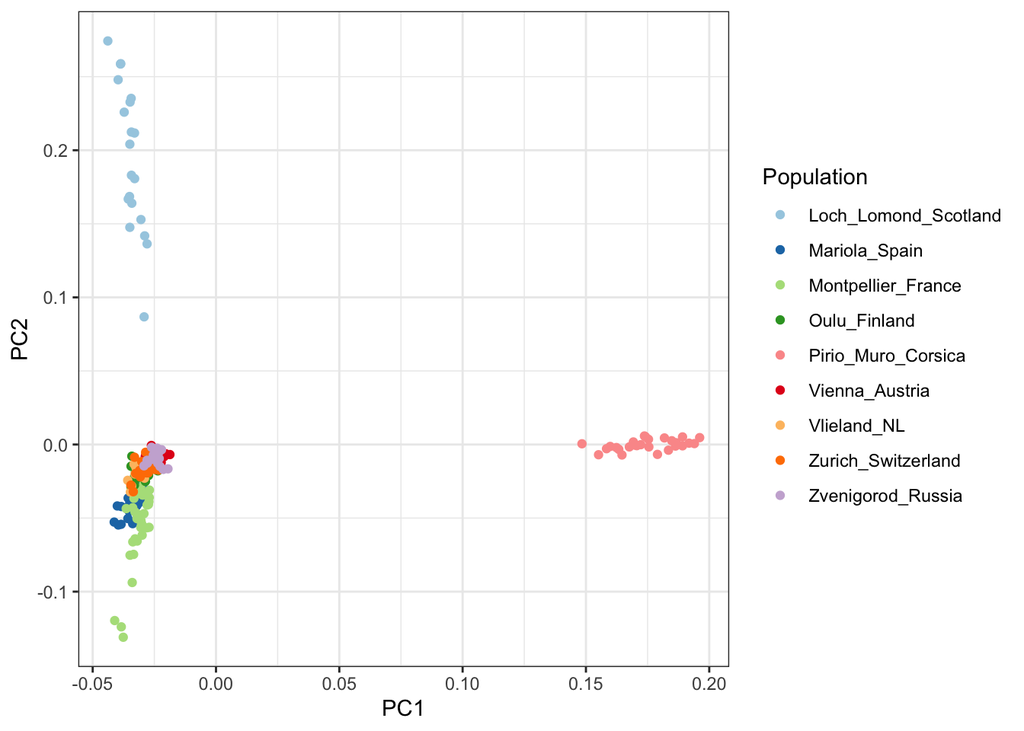

```r
  mycols <- c("#a6cee3",
              "#1f78b4",
              "#b2df8a",
              "#33a02c",
              "#fb9a99",
              "#e31a1c",
              "#fdbf6f",
              "#ff7f00",
              "#cab2d6")

B <- ggplot(pca1,aes(x = PC1,y = PC2,col = Population))+
      geom_point()+
      theme_bw()+
      scale_colour_manual(values = mycols)
B
```

Now we are onto the tricky part - the admixture plots. Rather than take you through this step by step I have provided a function that I have written myself. This is in the “Admixture_plot.R” script that you downloaded. Open the script up and take a look at the code. We will not go into writing functions here, but essentially this script contains the code to create a function called `admixtureplot()`. After you have run the code in the script you will then be able to use the function. Running the code manually would work, but you would need to do this every time you ran the script you are currently working on. You could copy and paste the function code into your current script, but that would be rather unwieldy. We will use the following code:

```r
source("Admixture_plot.R")
```

If you look in the “environment” tab in the top right of R studio, you should see that the `admixtureplot()` function has been loaded. You can call up the code by typing `admixtureplot` (without brackets) into the console.

Now we are ready to try running the function. `admixtureplot` has 4 arguments, three of which are mandatory. `str_out` is your “.Q” file from admixture, loaded into R as a data frame, “pops” is the “.fam” plink file associated with the “.bed” file used to run admixture. `k` is simply the value of k for the run, and `xaxis` is an optional argument with which we can tell the function whether or not to plot x axis labels.

Adapt the following code (depending on your working directory) to run the function for your K = 2 admixture output.

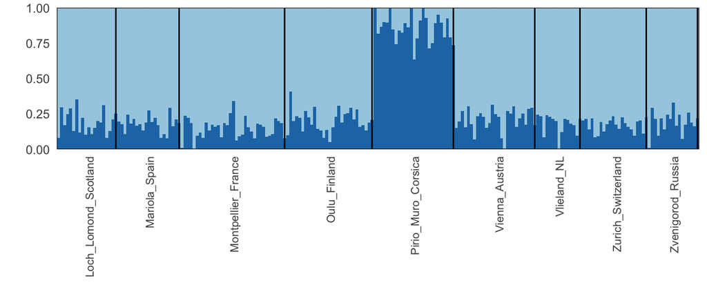

```r
K2 <- read_delim("GreatTitsThinned.2.Q", delim = " ",col_names = F)
mypops <- read_delim("GreatTitsThinned.fam", delim = " ",col_names = F)
C <- admixtureplot(str_out = K2,k = 2, pops = mypops)

C
```

Now it should be fairly clear how we can do the same thing for K = 3 and 4, and thus create the plots in our original figure. Remember that we only want x axis labels for the K = 4 plot.

```r
K2 <- read_delim("GreatTitsThinned.2.Q", delim = " ",col_names = F)
C <- admixtureplot(str_out = K2,k = 2, pops = mypops, xaxis = F)

K3 <- read_delim("GreatTitsThinned.3.Q", delim = " ", col_names = F)
D <- admixtureplot(str_out = K3,k = 3, pops = mypops, xaxis = F)

K4 <- read_delim("GreatTitsThinned.4.Q", delim = " ", col_names = F)
E <- admixtureplot(str_out = K4,k = 4, pops = mypops, xaxis = T)
```

Now all we need to do is put our five plots together, using `plot_grid()`. This is a bit more tricky is we have two plots on the left and three on the right. The easiest way is to first make the left and right columns separately.

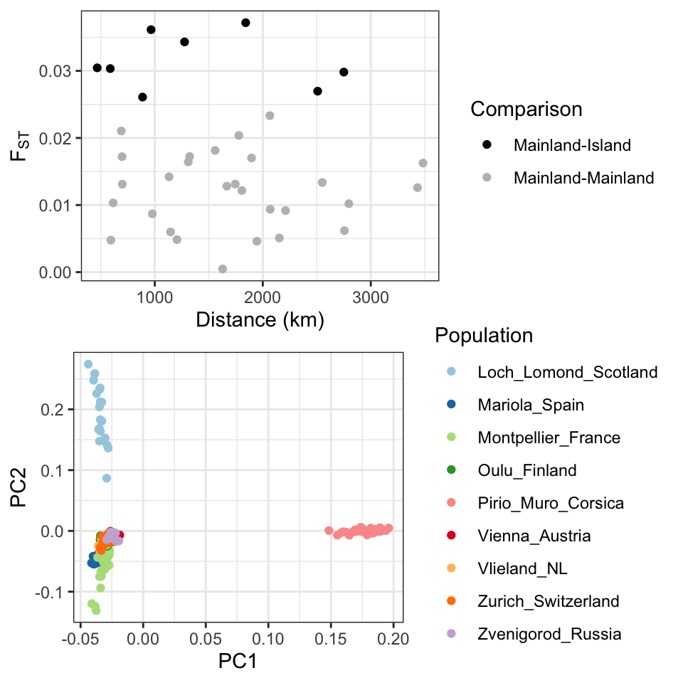

```r
left_col <- plot_grid(A,B,nrow = 2)
right_col <- plot_grid(C,D,E,nrow = 3)

left_col
```

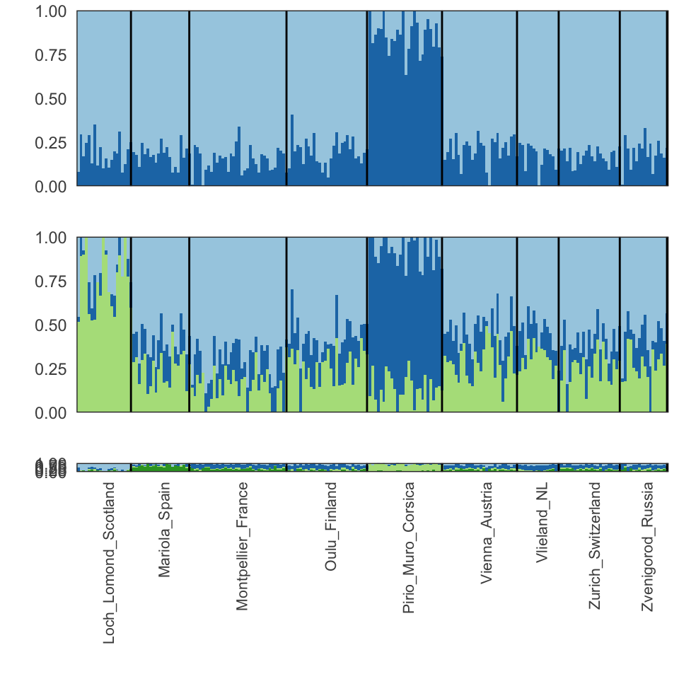

```r
right_col
```

These are almost there, but because only one of our three admixture plots has x axis labels, we need to ascribe more space to this panel. Can you figure out a way to do this, using the help for `plot_grid()`?

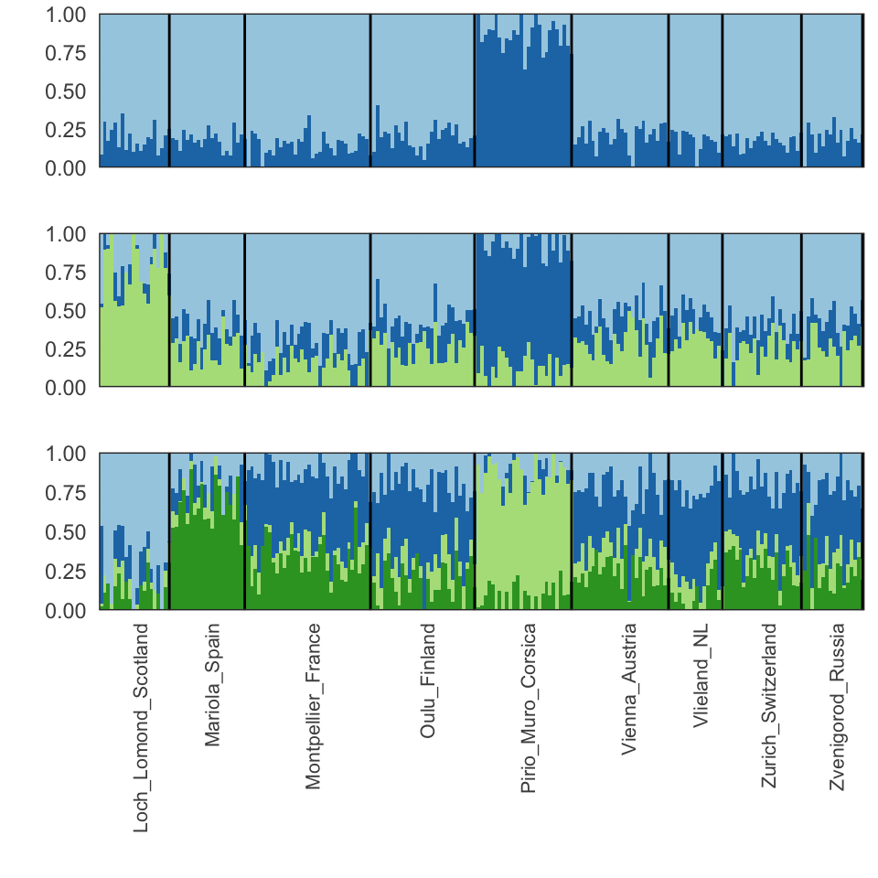

```r
right_col <- plot_grid(C,D,E,nrow = 3,rel_heights = c(0.5,0.5,1))

right_col
```

Now we can use an additonal `plot_grid()` function to make our final figure:

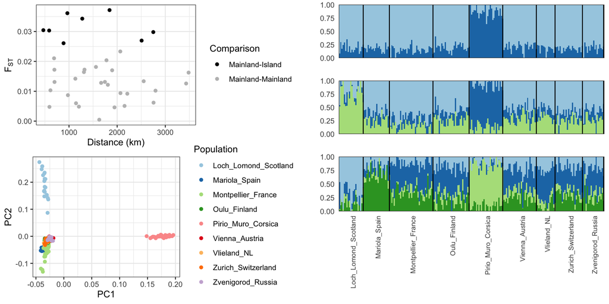

```r
plot_grid(left_col,right_col,ncol = 2)
```

## If you’ve finished

- Load the `ecodist` library and test whether FST and distance are correlated using a Mantel test, and a partial Mantel test including the “Comparison” variable.
- Plot PC3 and PC4 from the PCA
- Log back onto the server and try to estimate the CV error for each of your admixture analyses. Extract this information and plot CV error versus K (look up online if you don’t know what CV error is)
- Adapt my admixture plot script to change colours, ordering etc., or write your own.